# Magic Analysis: OVCAR4 isoline

## Introduction

Goal: to compare the difference in transcription factor enrichment between sensitive and resistant cell lines across three different tumor lines.

RNA-seq was run for isogenic tumor cell lines Sample preparation was performed in Dr. Lang’s lab. Preparation of cells and RNA extraction was done by Kendra, Josie, and Sydney. RNA seq library prep was done by Kristen.

This notebook is based on [this training](https://hbctraining.github.io/DGE_workshop/lessons/08_DGE_LRT.html) and a discussion with Avtar.

Biological Questions:

- How does transcription factor enrichment differ between these cellines?
- How does transcription factor enrichment differ between the sensitive and resistant cell lines

```r
isoline <- params$isoline
cont <- params$controlCellLine
exps <- params$experimentalCellLines
countmatrix.all <- params$countmatrix.all
metadata.all <- params$metadata.all
rm(params) # Remove the parameters so that we can make subsequent parameterized calls
```

## Gather and organize raw data

```r
metadata.isoline <- metadata.all %>%
  filter(IsoLine == isoline)
as.data.frame(metadata.isoline)
```

|  | ShortName | IsoLine | CellLine | Replicate | LongName | IsogenicRank | Resistant |
| --- | --- | --- | --- | --- | --- | --- | --- |
| OVCAR4_R1 | OVCAR4_R1 | OVCAR4 | OVCAR4 | 1 | OVCAR4_rep1 | 1 | 0 |
| OVCAR4_R2 | OVCAR4_R2 | OVCAR4 | OVCAR4 | 2 | OVCAR4_rep2 | 1 | 0 |
| OVCAR4_R3 | OVCAR4_R3 | OVCAR4 | OVCAR4 | 3 | OVCAR4_rep3 | 1 | 0 |
| OVCAR4A_R1 | OVCAR4A_R1 | OVCAR4 | OVCAR4A | 1 | OVCAR4ResA_rep1 | 2 | 1 |
| OVCAR4A_R2 | OVCAR4A_R2 | OVCAR4 | OVCAR4A | 2 | OVCAR4ResA_rep2 | 2 | 1 |
| OVCAR4A_R3 | OVCAR4A_R3 | OVCAR4 | OVCAR4A | 3 | OVCAR4ResA_rep3 | 2 | 1 |
| OVCAR4B_R1 | OVCAR4B_R1 | OVCAR4 | OVCAR4B | 1 | OVCAR4ResB_rep1 | 3 | 1 |
| OVCAR4B_R2 | OVCAR4B_R2 | OVCAR4 | OVCAR4B | 2 | OVCAR4ResB_rep2 | 3 | 1 |
| OVCAR4B_R3 | OVCAR4B_R3 | OVCAR4 | OVCAR4B | 3 | OVCAR4ResB_rep3 | 3 | 1 |

```r
countmatrix.isoline <- countmatrix.all[, metadata.isoline$ShortName]
as.data.frame(countmatrix.isoline)
```

|  | OVCAR4_R1 | OVCAR4_R2 | OVCAR4_R3 | OVCAR4A_R1 | OVCAR4A_R2 | OVCAR4A_R3 | OVCAR4B_R1 | OVCAR4B_R2 | OVCAR4B_R3 |
| --- | --- | --- | --- | --- | --- | --- | --- | --- | --- |
| A1BG | 68 | 123 | 89 | 202 | 107 | 86 | 21 | 15 | 13 |
| A1BG.AS1 | 96 | 59 | 69 | 144 | 155 | 133 | 45 | 57 | 52 |
| A1CF | 0 | 0 | 0 | 0 | 0 | 0 | 0 | 0 | 0 |
| A2M | 1 | 0 | 2 | 3 | 0 | 1 | 0 | 7 | 6 |
| A2M.AS1 | 18 | 11 | 10 | 6 | 5 | 11 | 14 | 13 | 8 |
| A2ML1 | 1 | 0 | 1 | 6 | 18 | 26 | 0 | 0 | 2 |
| A2MP1 | 0 | 0 | 0 | 0 | 0 | 0 | 0 | 0 | 0 |
| A3GALT2 | 0 | 0 | 0 | 0 | 0 | 0 | 0 | 0 | 0 |
| A4GALT | 163 | 201 | 154 | 211 | 254 | 247 | 170 | 354 | 370 |
| A4GNT | 0 | 0 | 0 | 0 | 0 | 0 | 0 | 0 | 0 |

[output cut: 990 more lines]

Create a cls file with cell line categorization information

```r
possible_categories <- unique(metadata.isoline$CellLine)
assigned_categories <- metadata.isoline$CellLine
num_categories <- length(possible_categories)
num_samples <- length(assigned_categories)

fileConn<-file(str_interp("data/${isoline}_celllines.cls"))
writeLines(
  c(
    str_interp("${num_samples}\t${num_categories}\t1"),
    str_interp("#\t${paste(possible_categories, collapse='\t')}"),
    str_interp("${paste(assigned_categories, collapse='\t')}")),
  fileConn)
close(fileConn)
```

## Filter out low-read genes to create our background gene set

Only retain genes for which there is a cell line that had at least 1 read for the gene in all of its replicates

```r
str_interp("${nrow(countmatrix.isoline)} genes before filtration.")
```

```
[1] "29744 genes before filtration."
```

```
29744 genes before filtration.
```

```r
countmatrix.isoline.df <- as.data.frame(countmatrix.isoline)
for(row in 1:nrow(countmatrix.isoline.df)) {
  keepGene <- FALSE

  # for at least one of the cell lines
  for (cellline in append(exps, cont)) {
    allRead <- TRUE

    # all of the replicates must have at least one read
    for(i in 1:3) {
      sampleName <- str_interp("${cellline}_R${i}")
      if (countmatrix.isoline.df[row, sampleName] < 1) {
        allRead <- FALSE
      }
    }

    if (allRead) {
      keepGene <- TRUE
    }
  }

  if (keepGene) {
    countmatrix.isoline.df$SufficientReads[row] <- TRUE
  } else {
    countmatrix.isoline.df$SufficientReads[row] <- FALSE
  }
}

countmatrix.isoline.filtered <- countmatrix.isoline.df %>%
  filter(SufficientReads)

str_interp("${nrow(countmatrix.isoline.filtered)} genes after filtration.")
```

```
[1] "17426 genes after filtration."
```

```
17426 genes after filtration.
```

```r
backgroundGenes.isoline <- rownames(countmatrix.isoline.filtered)
```

## Differential expression analysis

Run Deseq on the data set.

```r
# Having the replicate number in the design makes it a paired design
if (length(exps) == 1) {
  dds.isoline <- DESeqDataSetFromMatrix(countData = countmatrix.isoline, colData = metadata.isoline, design = ~ CellLine + Replicate)
} else {
  dds.isoline <- DESeqDataSetFromMatrix(countData = countmatrix.isoline, colData = metadata.isoline, design = ~ CellLine + Replicate)
}
```

```
  the design formula contains one or more numeric variables with integer values,
  specifying a model with increasing fold change for higher values.
  did you mean for this to be a factor? if so, first convert
  this variable to a factor using the factor() function
```

```
factor levels were dropped which had no samples
```

Using a Likelihood Ratio Test rather than the Wald test allows us to analyze all cellLines at once (rather than analyzing them pair-wise). P-values are determined only by the difference in performance of the full and reduced models. This answers whether the cell line explains a significant amount of variation in the gene expression. We can then examine the two resistant cell lines as compared to the nonresistant line.

```r
if (length(exps) == 1) {
  dds.isoline$CellLine <- relevel(dds.isoline$CellLine, ref = toString(cont)) # sets the nonresistant cell line as the control
  dds.isoline <- DESeq(dds.isoline) # If only two cell lines to compare we can use a PWald test
} else {
  # Full model includes  Replicate + CellLine; Reduced model only includes Replicate
  dds.isoline <- DESeq(dds.isoline, test="LRT", reduced = ~ Replicate)
}
```

## Filter and normalize deseq output

Filter out the low read genes that are not included in our background gene list.

```r
# Filter (recalculates p-adjusted values automatically)
dds.isoline.filtered <- subset(dds.isoline, rownames(dds.isoline) %in% backgroundGenes.isoline)

# Pull out results
if (length(exps) == 1) {
  res.isoline.lrt.filtered <- results()
} else {
  res.isoline.lrt.filtered <- results(dds.isoline.filtered)
}
res.isoline.lrt.filtered <- as.data.frame(res.isoline.lrt.filtered[order(res.isoline.lrt.filtered$padj, decreasing = FALSE),])

as.data.frame(res.isoline.lrt.filtered)
```

|  | baseMean | log2FoldChange | lfcSE | stat | pvalue | padj |
| --- | --- | --- | --- | --- | --- | --- |
| FBN2 | 2736.31074 | 0.0226395056 | 0.11444292 | 1693.46221 | 0.000000e+00 | 0.000000e+00 |
| HEY2 | 685.69973 | -0.0921402947 | 0.18725725 | 1096.90033 | 6.473217e-239 | 5.294444e-235 |
| EMX2OS | 2323.22449 | -0.1741148240 | 0.12034777 | 983.67708 | 2.495949e-214 | 1.360958e-210 |
| UCHL1 | 1481.59280 | 0.1878281226 | 0.07162605 | 947.53199 | 1.762147e-206 | 7.206302e-203 |
| MYL9 | 2102.76331 | 0.0709042835 | 0.14542478 | 890.42783 | 4.426434e-194 | 1.448152e-190 |
| SEMA6A | 360.48653 | 0.1287006727 | 0.21337586 | 804.10262 | 2.462269e-175 | 6.712966e-172 |
| LMO3 | 1420.13818 | -0.0311680454 | 0.11667585 | 796.62540 | 1.035123e-173 | 2.418934e-170 |
| PLOD2 | 5815.79395 | -0.1028383247 | 0.07075015 | 683.55406 | 3.699312e-149 | 7.564168e-146 |
| NREP | 780.16770 | -0.0154135348 | 0.10770400 | 682.76114 | 5.499241e-149 | 9.995177e-146 |
| MAGED4B | 215.08210 | -0.0254557925 | 0.24072357 | 580.70236 | 7.981485e-127 | 1.305611e-123 |

[output cut: 990 more lines]

```r
# Pull out only significant results
sig.res.isoline.lrt.filtered <- res.isoline.lrt.filtered %>% filter(padj < 0.05)
sig.res.isoline.lrt.filtered
```

|  | baseMean | log2FoldChange | lfcSE | stat | pvalue | padj |
| --- | --- | --- | --- | --- | --- | --- |
| FBN2 | 2736.31074 | 0.0226395056 | 0.11444292 | 1693.46221 | 0.000000e+00 | 0.000000e+00 |
| HEY2 | 685.69973 | -0.0921402947 | 0.18725725 | 1096.90033 | 6.473217e-239 | 5.294444e-235 |
| EMX2OS | 2323.22449 | -0.1741148240 | 0.12034777 | 983.67708 | 2.495949e-214 | 1.360958e-210 |
| UCHL1 | 1481.59280 | 0.1878281226 | 0.07162605 | 947.53199 | 1.762147e-206 | 7.206302e-203 |
| MYL9 | 2102.76331 | 0.0709042835 | 0.14542478 | 890.42783 | 4.426434e-194 | 1.448152e-190 |
| SEMA6A | 360.48653 | 0.1287006727 | 0.21337586 | 804.10262 | 2.462269e-175 | 6.712966e-172 |
| LMO3 | 1420.13818 | -0.0311680454 | 0.11667585 | 796.62540 | 1.035123e-173 | 2.418934e-170 |
| PLOD2 | 5815.79395 | -0.1028383247 | 0.07075015 | 683.55406 | 3.699312e-149 | 7.564168e-146 |
| NREP | 780.16770 | -0.0154135348 | 0.10770400 | 682.76114 | 5.499241e-149 | 9.995177e-146 |
| MAGED4B | 215.08210 | -0.0254557925 | 0.24072357 | 580.70236 | 7.981485e-127 | 1.305611e-123 |

[output cut: 990 more lines]

```r
# Subset the dds for significant results
sigGenes.isoline <- rownames(sig.res.isoline.lrt.filtered)
dds.isoline.filtered.sig <- subset(dds.isoline.filtered, rownames(dds.isoline.filtered) %in% sigGenes.isoline)
```

Normalize the data using the median of ratios method and vst methods. Chosen based on [this training](https://nbisweden.github.io/workshop-RNAseq/1906/lab_dge.html)

```r
# Normalize using the median of ratios method, which incorporates sequencing depth and compositional bias
normalized_counts.isoline.filtered <- counts(dds.isoline.filtered, normalized=TRUE)
normalized_counts.isoline.lrt.filtered.sig <- counts(dds.isoline.filtered.sig, normalized=TRUE)
as.data.frame(counts(dds.isoline.filtered)) # non-normalized
```

|  | OVCAR4_R1 | OVCAR4_R2 | OVCAR4_R3 | OVCAR4A_R1 | OVCAR4A_R2 | OVCAR4A_R3 | OVCAR4B_R1 | OVCAR4B_R2 | OVCAR4B_R3 |
| --- | --- | --- | --- | --- | --- | --- | --- | --- | --- |
| A1BG | 68 | 123 | 89 | 202 | 107 | 86 | 21 | 15 | 13 |
| A2ML1 | 1 | 0 | 1 | 6 | 18 | 26 | 0 | 0 | 2 |
| A4GALT | 163 | 201 | 154 | 211 | 254 | 247 | 170 | 354 | 370 |
| AAAS | 1395 | 946 | 1078 | 1032 | 1032 | 1168 | 831 | 1333 | 1425 |
| AACS | 638 | 290 | 418 | 527 | 878 | 945 | 513 | 1365 | 1643 |
| AADAT | 197 | 54 | 104 | 166 | 137 | 190 | 143 | 243 | 240 |
| AAED1 | 848 | 364 | 570 | 484 | 516 | 628 | 404 | 704 | 762 |
| AAGAB | 3072 | 1128 | 1749 | 1434 | 2665 | 3122 | 904 | 2709 | 3243 |
| AAK1 | 2073 | 1219 | 1503 | 1724 | 2698 | 3677 | 1745 | 4202 | 4379 |
| AAMDC | 83 | 91 | 112 | 216 | 156 | 193 | 193 | 251 | 252 |

[output cut: 990 more lines]

```r
as.data.frame(normalized_counts.isoline.filtered) # normalized
```

|  | OVCAR4_R1 | OVCAR4_R2 | OVCAR4_R3 | OVCAR4A_R1 | OVCAR4A_R2 | OVCAR4A_R3 | OVCAR4B_R1 | OVCAR4B_R2 | OVCAR4B_R3 |
| --- | --- | --- | --- | --- | --- | --- | --- | --- | --- |
| A1BG | 5.954880e+01 | 2.022084e+02 | 1.166911e+02 | 2.047119e+02 | 9.256579e+01 | 6.838808e+01 | 2.880145e+01 | 1.122945e+01 | 9.067811e+00 |
| A2ML1 | 8.757176e-01 | 0.000000e+00 | 1.311136e+00 | 6.080551e+00 | 1.557182e+01 | 2.067547e+01 | 0.000000e+00 | 0.000000e+00 | 1.395048e+00 |
| A4GALT | 1.427420e+02 | 3.304381e+02 | 2.019150e+02 | 2.138327e+02 | 2.197356e+02 | 1.964169e+02 | 2.331546e+02 | 2.650150e+02 | 2.580839e+02 |
| AAAS | 1.221626e+03 | 1.555196e+03 | 1.413405e+03 | 1.045855e+03 | 8.927841e+02 | 9.288056e+02 | 1.139714e+03 | 9.979239e+02 | 9.939716e+02 |
| AACS | 5.587078e+02 | 4.767516e+02 | 5.480550e+02 | 5.340750e+02 | 7.595586e+02 | 7.514737e+02 | 7.035782e+02 | 1.021880e+03 | 1.146032e+03 |
| AADAT | 1.725164e+02 | 8.877443e+01 | 1.363582e+02 | 1.682286e+02 | 1.185188e+02 | 1.510900e+02 | 1.961241e+02 | 1.819171e+02 | 1.674057e+02 |
| AAED1 | 7.426085e+02 | 5.984054e+02 | 7.473478e+02 | 4.904977e+02 | 4.463920e+02 | 4.993921e+02 | 5.540850e+02 | 5.270356e+02 | 5.315132e+02 |
| AAGAB | 2.690205e+03 | 1.854399e+03 | 2.293178e+03 | 1.453252e+03 | 2.305494e+03 | 2.482647e+03 | 1.239834e+03 | 2.028039e+03 | 2.262070e+03 |
| AAK1 | 1.815363e+03 | 2.004000e+03 | 1.970638e+03 | 1.747145e+03 | 2.334042e+03 | 2.923988e+03 | 2.393263e+03 | 3.145744e+03 | 3.054457e+03 |
| AAMDC | 7.268456e+01 | 1.496013e+02 | 1.468473e+02 | 2.188998e+02 | 1.349557e+02 | 1.534756e+02 | 2.646990e+02 | 1.879061e+02 | 1.757760e+02 |

[output cut: 990 more lines]

```r
write.table(
  as.data.frame(normalized_counts.isoline.filtered),
  file=str_interp("data/${isoline}_filtered_normalized_counts.txt"),
  sep="\t",
  quote=F,
  col.names=NA)

write.table(
  as.data.frame(normalized_counts.isoline.lrt.filtered.sig),
  file=str_interp("data/${isoline}_filtered_sig_normalized_counts.txt"),
  sep="\t",
  quote=F,
  col.names=NA)

# Normalize using vst, which results in similar variance across samples. This is needed for PCA analysis
vst.dds.isoline.filtered <- vst(dds.isoline.filtered)
vst.dds.isoline.filtered.sig <- vst(dds.isoline.filtered.sig)
```

## PCA Plots

All background genes. This plots the vst of the counts.

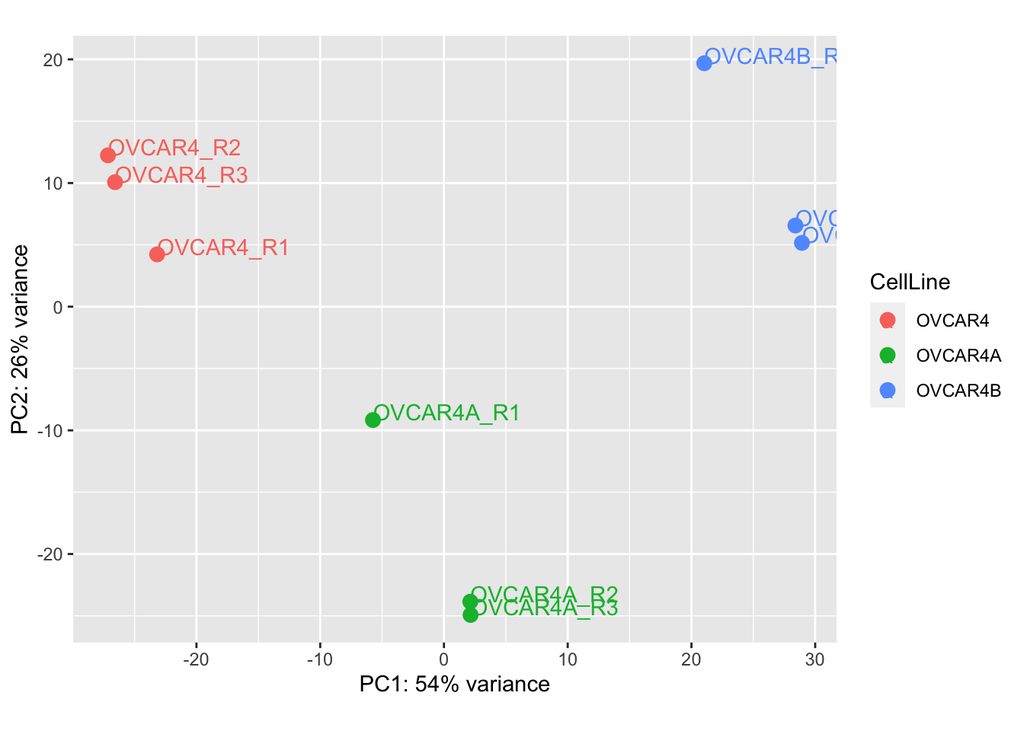

```r
pcaData <- plotPCA(vst.dds.isoline.filtered, intgroup = c("CellLine", "ShortName"), returnData = TRUE)
percentVar <- round(100 * attr(pcaData, "percentVar"))
ggplot(pcaData, aes(PC1, PC2, color = CellLine, label = ShortName)) +
  geom_point(size = 3) +
  geom_text(hjust = 0, vjust = 0) +
  xlab(paste0("PC1: ", percentVar[1], "% variance")) +
  ylab(paste0("PC2: ", percentVar[2], "% variance")) +
  coord_fixed()
```

Only significant genes. This plots the vst of the counts.

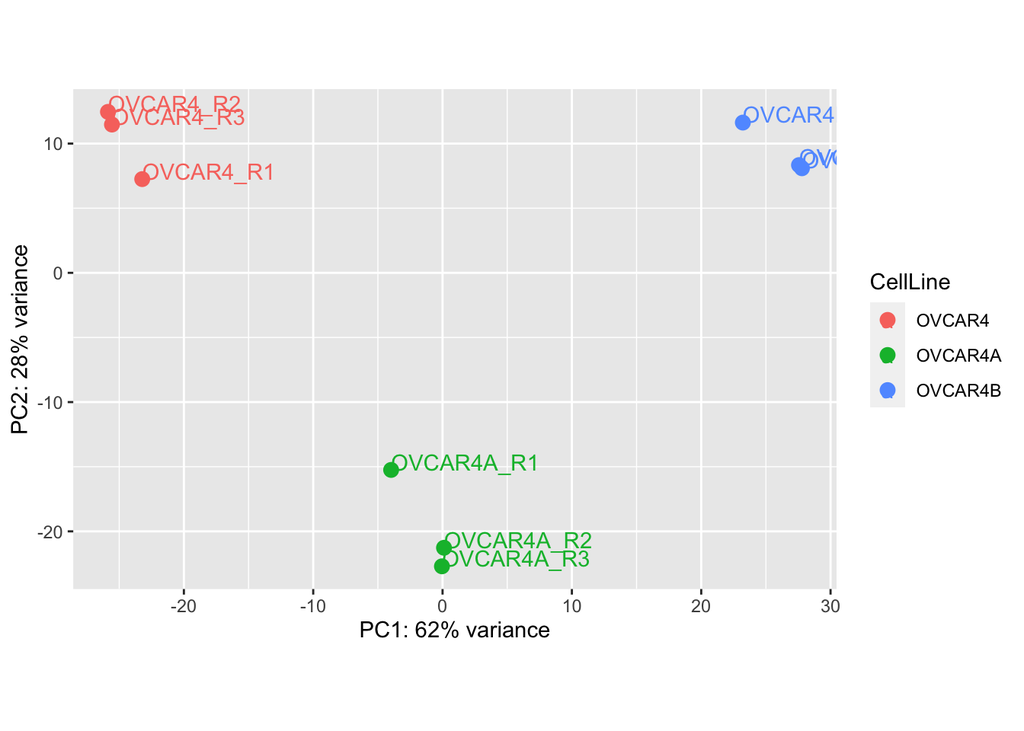

```r
pcaData <- plotPCA(vst.dds.isoline.filtered.sig, intgroup = c("CellLine", "ShortName"), returnData = TRUE)
percentVar <- round(100 * attr(pcaData, "percentVar"))
ggplot(pcaData, aes(PC1, PC2, color = CellLine, label = ShortName)) +
  geom_point(size = 3) +
  geom_text(hjust = 0, vjust = 0) +
  xlab(paste0("PC1: ", percentVar[1], "% variance")) +
  ylab(paste0("PC2: ", percentVar[2], "% variance")) +
  coord_fixed()
```

# Cluster using Leiden clustering (script courtesy of Avtar)

Copy output into gene_clusters folder: cp data/OVCAR4_filtered_sig_normalized_counts_clusters/clusters_centered.pdf gene_clusters/OVCAR4_gene_clusters_centered.pdf cp data/OVCAR4_filtered_sig_normalized_counts_clusters/gene_cluster_lists.TSV gene_clusters/OVCAR4_gene_cluster_s_centered.pdf_lists.TSV